# Francesco/Esteves/Valle Model — Complete Analysis with Sector Benchmarks

Evaluates the **Francesco/Esteves/Valle Model** portfolio optimized against benchmarks from the **11 GICS sectors (Global Industry Classification Standard)** (equal-weighted return of each S&P 500 sector).

| Model | Optimization Benchmark |
| --- | --- |
| **Francesco/Esteves/Valle Model** | Synthetic Benchmark = max_k(cumsum sorted) of the 11 sectors |
| **Roman Model (Scaled)** | SP500 (reference) |
| **Francesco/Esteves/Valle Model (Factors)** | Synthetic Benchmark of Fama-French factors |

## Experiment Settings

| Parameter | Value |
| --- | --- |
| **Model** | TAF-MultiSSD (tafmSSD) — multi-benchmark SSD, synthetic benchmark (*max_k* operator) |
| **Formulation** | MIP with lazy constraints (CPLEX callback; dummy binary var `cb_temp`) |
| **In-sample window** | 200 days (sliding window) |
| **Universe** | ~505 S&P 500 constituent assets (after removing >15% missing values) |
| **Benchmark** | Synthetic = max_k(cumsum sorted) of the 11 GICS sectors |
| **Rebalancing frequency** | Every 21 business days |
| **Out-of-sample period** | 2024-01-02 to 2024-06-01 |
| **Number of rebalancings** | 5 |
| **Transaction costs** | None |
| **Minimum lots** | None |

**Structure:**

1. Setup
2. Data and model loading
3. Market context — OOS sectors
4. Synthetic Benchmark OOS — dominant sector
5. Constraint tightness — τ_k per sector per window
6. Dominant sector by rank
7. Overview — portfolio vs sectors
8. Comparative drawdown
9. OOS metrics — complete table
10. SSD dominance 10b. SSD dominance — CDFs and cumulative integrals (Francesco/Esteves/Valle Model) 10c. r_P vs r_B by quantile — tail analysis
11. Risk × return analysis
12. Distribution and correlation
13. Rolling returns
14. Executive summary

## 1. Setup

```
ROOT: /media/toni/Dados/Git/ssd-multi
Available sectors (11): ['BASIC_MATERIALS', 'CONSUMER_CYCLICALS', 'CONSUMER_NON_CYCLICALS', 'ENERGY', 'FINANCIALS', 'HEALTHCARE', 'INDUSTRIALS', 'REAL_ESTATE', 'TECHNOLOGY', 'TELECOMMUNICATIONS_SERVICES', 'UTILITIES']
```

## 2. Data and model loading

```
Market data  : (305, 509)
OOS          : 2024-01-02 → 2024-05-31  (105 days)
Sectors      : (304, 11)
```

```
Loaded models (3):
  Francesco/Esteves/Valle Model             final = 1.6092  (+60.92%)
  Roman Model (Scaled)                      final = 1.4911  (+49.11%)
  Francesco/Esteves/Valle Model (Factors)   final = 1.2230  (+22.30%)
```

## 3. Market context — OOS sectors

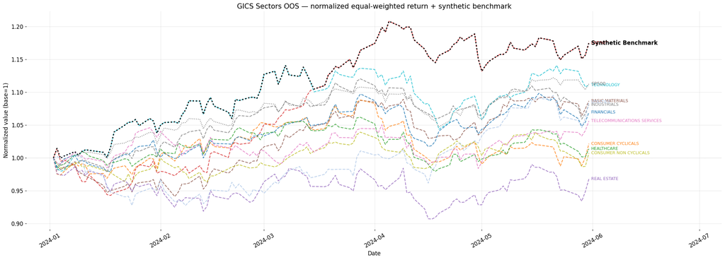

**Market context (overview of OOS sectors)**

```
[INFO]: Plot saved → /media/toni/Dados/Git/ssd-multi/src/output/tafmssd-sectors/market_context_basic_materials.pdf
```

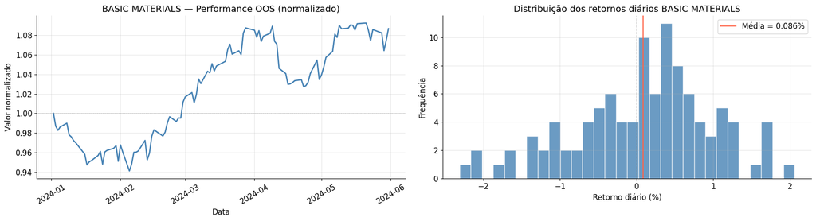

```
[INFO]: Plot saved → /media/toni/Dados/Git/ssd-multi/src/output/tafmssd-sectors/market_context_consumer_cyclicals.pdf
```

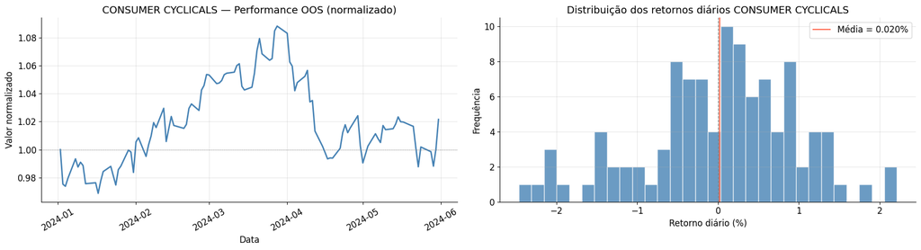

```
[INFO]: Plot saved → /media/toni/Dados/Git/ssd-multi/src/output/tafmssd-sectors/market_context_consumer_non_cyclicals.pdf
```

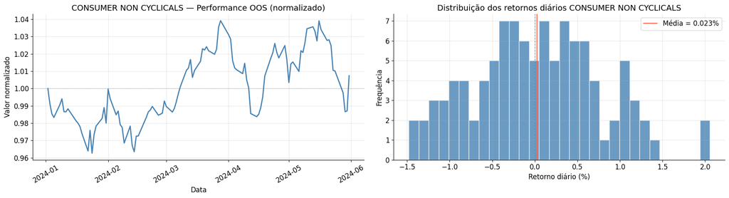

```
[INFO]: Plot saved → /media/toni/Dados/Git/ssd-multi/src/output/tafmssd-sectors/market_context_energy.pdf
```

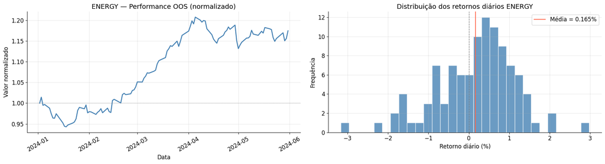

```
[INFO]: Plot saved → /media/toni/Dados/Git/ssd-multi/src/output/tafmssd-sectors/market_context_financials.pdf
```

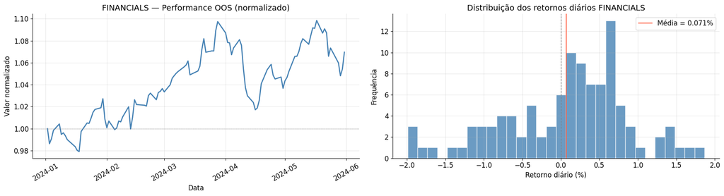

```
[INFO]: Plot saved → /media/toni/Dados/Git/ssd-multi/src/output/tafmssd-sectors/market_context_healthcare.pdf
```

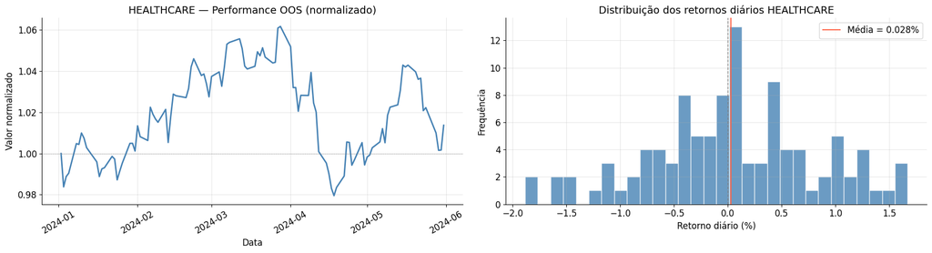

```
[INFO]: Plot saved → /media/toni/Dados/Git/ssd-multi/src/output/tafmssd-sectors/market_context_industrials.pdf
```

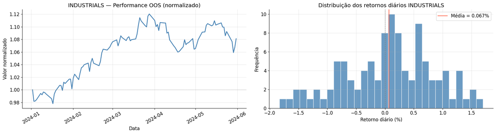

```
[INFO]: Plot saved → /media/toni/Dados/Git/ssd-multi/src/output/tafmssd-sectors/market_context_real_estate.pdf
```

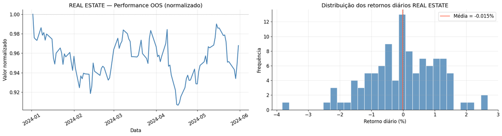

```
[INFO]: Plot saved → /media/toni/Dados/Git/ssd-multi/src/output/tafmssd-sectors/market_context_technology.pdf
```

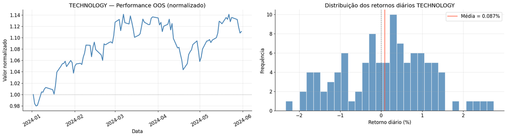

```
[INFO]: Plot saved → /media/toni/Dados/Git/ssd-multi/src/output/tafmssd-sectors/market_context_telecommunications_services.pdf
```

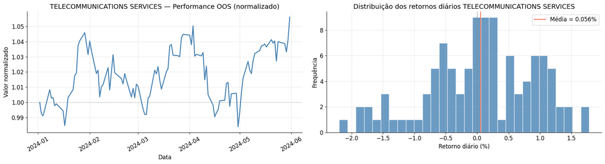

```
[INFO]: Plot saved → /media/toni/Dados/Git/ssd-multi/src/output/tafmssd-sectors/market_context_utilities.pdf
```

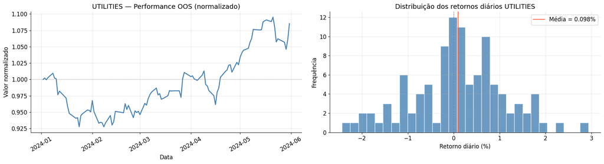

**Individual market context per sector**

Each panel combines the normalized series with the daily return distribution of a sector. Sectors with fat tails in their returns create the most demanding SSD constraints: the portfolio must accumulate sufficient returns even in the worst scenarios of that sector, so that the cumulative integral of the portfolio's sorted returns dominates the corresponding integral of the sector. Sectors with a pronounced positive trend in the OOS period are the most likely candidates to have been the binding constraint of the Synthetic Benchmark in some training window. Sectors with persistently negative returns (series below 1.0) were rarely binding — the portfolio dominated them by a wide margin, making their SSD constraints virtually inactive during optimization.

## 3b. Dominant sector per OOS day

```
Daily dominance frequency (which sector has the highest return on each OOS day):
  ENERGY                                   23 days  (21.9%)
  TECHNOLOGY                               22 days  (21.0%)
  UTILITIES                                16 days  (15.2%)
  CONSUMER_NON_CYCLICALS                    9 days  (8.6%)
  CONSUMER_CYCLICALS                        8 days  (7.6%)
  REAL_ESTATE                               8 days  (7.6%)
  BASIC_MATERIALS                           6 days  (5.7%)
  FINANCIALS                                5 days  (4.8%)
  TELECOMMUNICATIONS_SERVICES               4 days  (3.8%)
  HEALTHCARE                                3 days  (2.9%)
  INDUSTRIALS                               1 days  (1.0%)
```

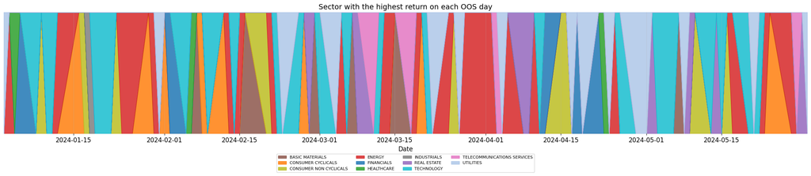

**Dominant sector per OOS day**

## 4. Synthetic Benchmark OOS — detailed analysis

The synthetic benchmark is `max_k(norm_k[t])` — the sector with the best normalized performance on each day. Each absolute in-sample point is `max_k(sorted_b_k[s])` (saved in `synthetic_bench-*.csv`).

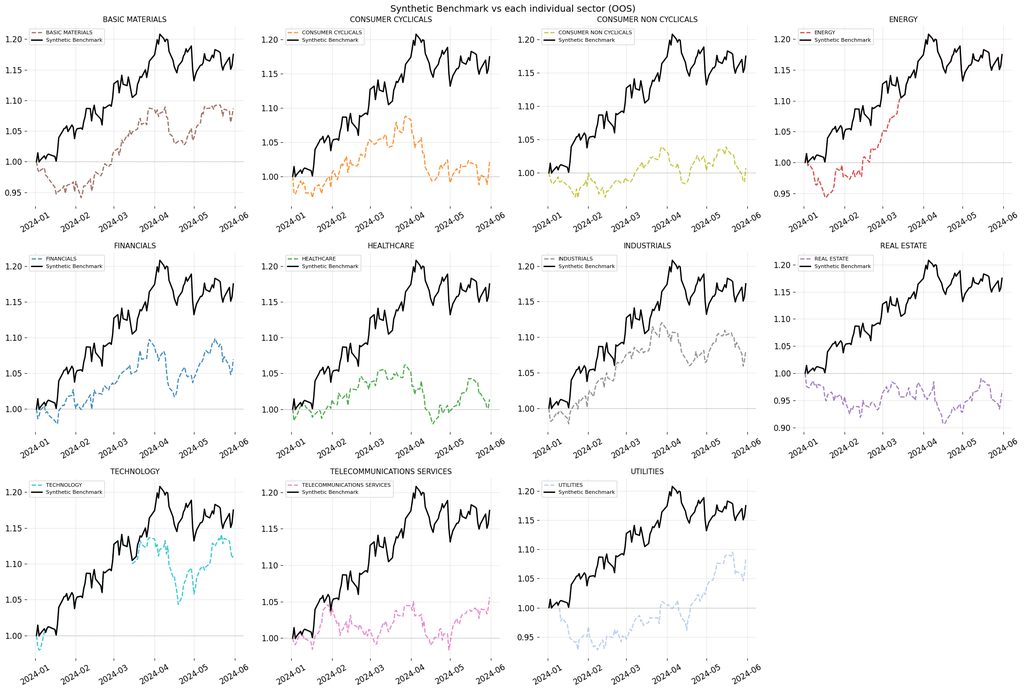

**Synthetic Benchmark vs each individual sector**

Each panel makes explicit the "slack" the model needed to cover in order to guarantee SSD dominance: the vertical distance between the Synthetic Benchmark (black) and the individual sector (colored) represents how far that sector fell below the maximum envelope at each point in time. Panels where the sector stays close to the Synthetic Benchmark identify the model's binding constraints — sectors that frequently determined the LP constraint level and therefore most influenced portfolio composition. Sectors far below the Synthetic Benchmark were rarely binding and the model dominated them with margin. The shape of the Synthetic Benchmark curve is especially informative: an ascending trajectory concentrated in the first days of the OOS implies in-sample constraints calibrated for early gains, while a curve rising at the end indicates that the most demanding scenario materialized only at the close of the period.

```
5 training windows found
```

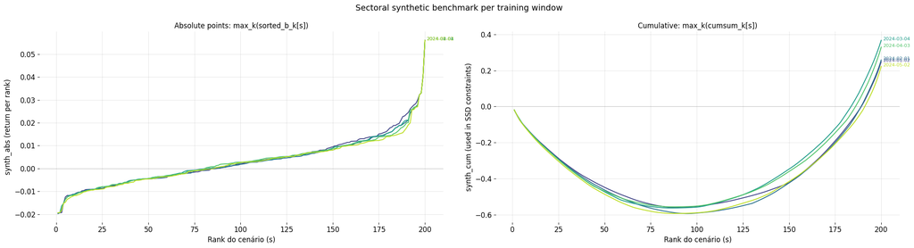

**Synthetic Benchmark per training window (absolute and cumulative curves)**

The left panel (`synth_abs`) shows the absolute return of the best sector at each rank s — from the worst to the best scenario within the training window. The right panel (`synth_cum`) displays the cumulative that enters directly into the LP's SSD constraints. Curves that cluster closely across distinct windows (overlapping viridis colors) indicate that the Synthetic Benchmark is stable over time, which favors consistency in the constraints at each rebalancing. The zero-crossing point in `synth_abs` delineates the boundary between loss and gain scenarios: a late crossing (many negative ranks) means that the worst scenarios of the Synthetic Benchmark concentrate significant losses, imposing very demanding constraints in the negative tails. The slope of `synth_cum` in the region of the worst ranks determines the "hardness" of the most difficult SSD constraints to satisfy — windows with a steep slope force the portfolio to maintain greater reserves of cumulative returns in downside scenarios. Divergence between windows signals qualitatively distinct market periods that generated different constraint structures for the solver.

## 5. Constraint tightness — τ_k per sector per training window

τ_k[s] = cumsum(sorted(sector_k_returns))[s] for each sector k. τ_synth[s] = max_k(τ_k[s]) — binding constraint at each rank s.

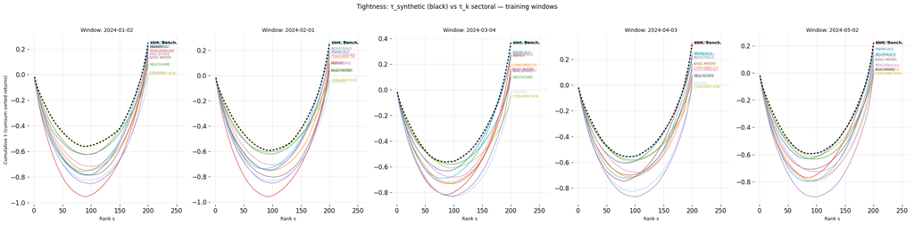

**Constraint tightness: τ_k per sector per training window**

For each training window, τ_k[s] is the cumulative of the s worst returns of sector k, and τ_synth[s] = max_k(τ_k[s]) is the upper envelope that determines the LP's effective constraints. A narrow gap between τ_synth and a specific sector indicates that sector was the binding constraint for the corresponding ranks: small changes in its returns would shift the constraint level. The variation of the gap across ranks reveals whether a given sector is binding only in the tails (worst scenarios) or throughout the entire distribution — information relevant for understanding where the model concentrated its "optimization effort." τ_synth inevitably takes negative values at the first ranks (worst returns summed), but the magnitude of this negativity matters: a very negative τ_synth in the tails makes the SSD constraints for the worst scenarios nearly intractable without sacrificing the middle ranks. Abrupt changes in τ_synth between consecutive windows signal instability in the constraints, which may translate into high portfolio turnover at each rebalancing.

## 6. Dominant sector by rank — which sector is binding at each rank s?

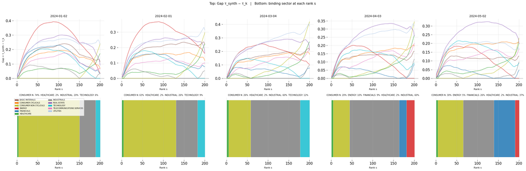

**Dominant sector by rank s (which sector is binding at each rank)**

The upper panel (gap τ_synth − τ_k) and the lower panel (binding sector at each rank) reveal the internal structure of the Synthetic Benchmark in each training window. When the lower color panel displays a single sector dominating most ranks (wide blocks of a single color), the Synthetic Benchmark is effectively uni-sectoral for that window — equivalent in practice to optimizing against that sector in isolation. High fragmentation indicates a genuinely multi-sectoral Synthetic Benchmark: the portfolio must simultaneously defend against the worst scenarios of one sector and the best scenarios of another, making the optimization problem more complex. When multiple sectors compete for the binding position at the same rank (small gap in several sectors simultaneously), the Synthetic Benchmark is especially "hard" in that region of the distribution. Finally, variation in the dominant sector between consecutive windows explains abrupt changes in portfolio composition: at rebalancing, the solver is reacting to a qualitatively different constraint structure.

## 7. Overview — portfolio vs sectors

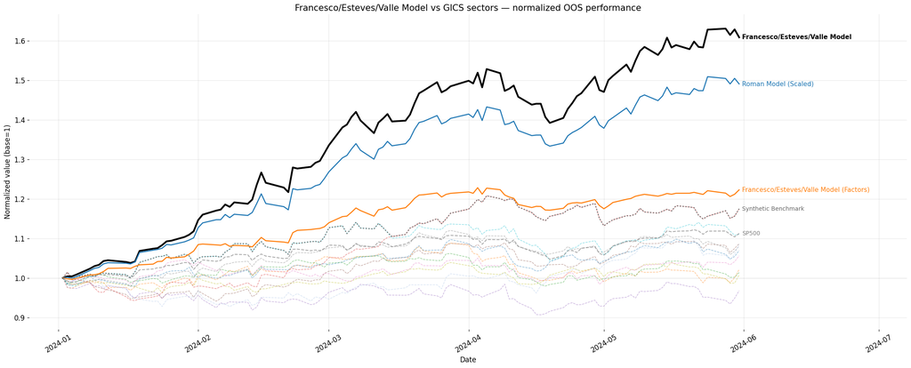

**Overview: portfolio vs GICS sectors**

## 8. Comparative drawdown

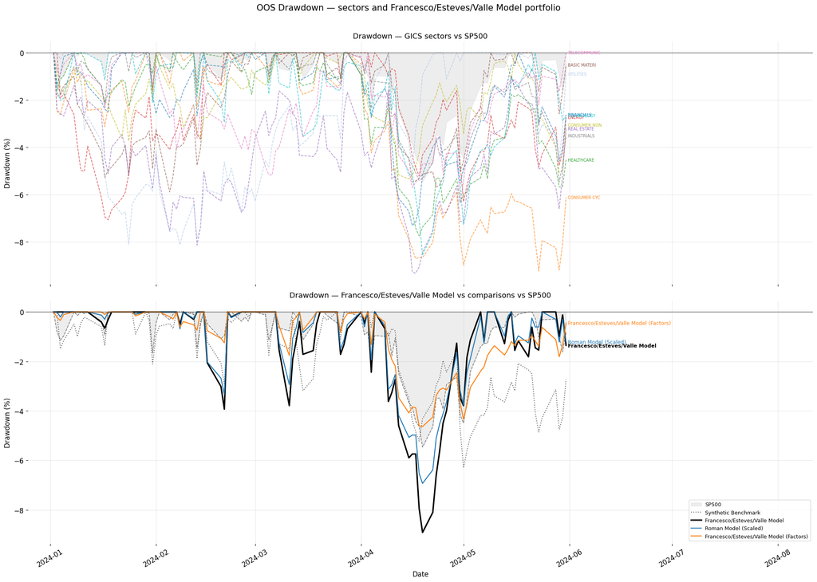

**Comparative drawdown**

The upper panel shows the drawdowns of the 11 sectors individually, providing the downside context of the benchmark universe. The lower panel compares the models with each other and with the Synthetic Benchmark. A portfolio optimized via SSD should exhibit smaller drawdowns than most individual sectors: the in-sample SSD dominance requirement forces diversification that tends to smooth out declines, though without an explicit maximum drawdown guarantee (this is not the objective of the formulation). The recovery speed after a drawdown is as informative as the depth: fast recoveries indicate a portfolio well-positioned to capture subsequent upside. The correlation of drawdowns between models is particularly relevant — simultaneous occurrence of maximum drawdowns in the Francesco/Esteves/Valle Model and the Roman Model suggests the event was systemic (independent of the benchmark), while divergence between the two models' drawdowns indicates that the choice of sectoral vs. SP500 benchmark makes a concrete difference in OOS downside behavior.

## 9. OOS metrics — complete table

|  | Final value | CAGR (%) | Volatility (%) | Daily CVaR 5% (%) | Sharpe Ratio | Sortino Ratio | Max Drawdown (%) | Portfolio beta |
| --- | --- | --- | --- | --- | --- | --- | --- | --- |
| SP500 | 1.1127 | 29.5400 | 11.3400 | 1.4070 | 1.9096 | 3.5279 | -5.4600 | 1.0000 |
| Synthetic Benchmark | 1.1750 | 47.8000 | 16.4800 | 1.9740 | 2.1585 | 4.1251 | -6.3000 | 1.0160 |
| Francesco/Esteves/Valle Model | 1.6092 | 216.6700 | 22.1400 | 2.3860 | 5.1060 | 17.3129 | -8.9100 | 1.1739 |
| Roman Model (Scaled) | 1.4911 | 163.2900 | 18.2900 | 1.9300 | 5.1260 | 15.2550 | -6.9300 | 1.0043 |
| Francesco/Esteves/Valle Model (Factors) | 1.2230 | 62.8800 | 10.2900 | 1.1700 | 4.3224 | 9.3841 | -4.6300 | 0.6071 |
| BASIC MATERIALS | 1.0867 | 22.3300 | 14.4600 | 1.9300 | 1.1288 | 1.8106 | -5.8900 | 0.7860 |
| CONSUMER CYCLICALS | 1.0215 | 5.3000 | 15.3700 | 2.1660 | 0.0949 | 0.0273 | -9.2300 | 1.0009 |
| CONSUMER NON CYCLICALS | 1.0073 | 1.7900 | 11.7300 | 1.3310 | -0.2070 | -0.4966 | -5.3400 | 0.3211 |
| ENERGY | 1.1750 | 47.8000 | 15.8100 | 2.0990 | 2.2436 | 3.8203 | -7.0600 | 0.5442 |
| FINANCIALS | 1.0696 | 17.7000 | 13.0200 | 1.7820 | 0.9421 | 1.3990 | -7.3000 | 0.6215 |
| HEALTHCARE | 1.0137 | 3.3600 | 12.3200 | 1.6520 | -0.0671 | -0.2052 | -7.7500 | 0.7289 |
| INDUSTRIALS | 1.0810 | 20.7800 | 12.4200 | 1.5730 | 1.1896 | 1.9940 | -5.4700 | 0.8723 |
| REAL ESTATE | 0.9679 | -7.6000 | 17.8400 | 2.4320 | -0.6279 | -1.0486 | -9.3200 | 0.8943 |
| TECHNOLOGY | 1.1108 | 28.9800 | 16.7900 | 1.8580 | 1.3094 | 2.4361 | -8.5500 | 1.3156 |
| TELECOMMUNICATIONS SERVICES | 1.0562 | 14.1600 | 13.8300 | 1.8280 | 0.6739 | 0.9862 | -6.3400 | 0.7683 |
| UTILITIES | 1.0853 | 21.9400 | 16.0700 | 2.0310 | 1.0106 | 1.6083 | -8.1100 | 0.3576 |

**OOS metrics (complete table)**

## 10. SSD dominance

```
Francesco/Esteves/Valle Model vs Synthetic Benchmark: min(SSD) = -0.044205  ✗ VIOLA
Roman Model (Scaled) vs SP500: min(SSD) = -0.074537  ✗ VIOLA
Francesco/Esteves/Valle Model (Factors) vs SP500: min(SSD) = +0.002830  ✓ DOMINA
[INFO]: Plot saved → /media/toni/Dados/Git/ssd-multi/src/output/tafmssd-sectors/ssd_home_dominance.pdf
```

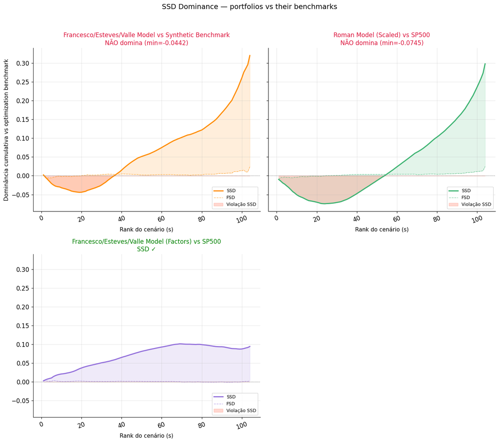

**SSD dominance: portfolios vs their optimization benchmarks**

This panel verifies whether each portfolio SSD-dominates its optimization benchmark in the OOS period. In-sample SSD dominance is guaranteed by the LP — the test here is generalization. For the Francesco/Esteves/Valle Model, the SSD curve should be ≥ 0 at all points to confirm OOS dominance against the sectoral Synthetic Benchmark; violations (negative regions) locate exactly where the benchmark outperformed the portfolio in the cumulative distribution. Violations in the left tails (worst scenarios) are the most concerning, as they indicate that the portfolio lost more than the benchmark on the worst OOS days — contrary to the fundamental objective of the formulation. Mild violations (min SSD close to zero) are acceptable given the temporal gap between in-sample and OOS. The comparison with the Roman Model (Scaled) vs SP500 provides the baseline: if the sectoral model shows OOS dominance similar to or better than the Roman Model, the use of sectoral benchmarks adds value without deteriorating the dominance property.

```
=== Francesco/Esteves/Valle Model: cross-dominance vs each sector ===
  Sector                                    min(SSD)    min(FSD)  Status
  ------------------------------------------------------------------------
  BASIC_MATERIALS                          -0.058905   -0.006457  ✗ VIOLA
  CONSUMER_CYCLICALS                       -0.027993   -0.004889  ✗ VIOLA
  CONSUMER_NON_CYCLICALS                   -0.117114   -0.014737  ✗ VIOLA
  ENERGY                                   -0.048470   -0.005736  ✗ VIOLA
  FINANCIALS                               -0.079776   -0.009654  ✗ VIOLA
  HEALTHCARE                               -0.101468   -0.010702  ✗ VIOLA
  INDUSTRIALS                              -0.101808   -0.011252  ✗ VIOLA
  REAL_ESTATE                              -0.000260   -0.002307  ✗ VIOLA
  TECHNOLOGY                               -0.035799   -0.006243  ✗ VIOLA
  TELECOMMUNICATIONS_SERVICES              -0.073409   -0.007564  ✗ VIOLA
  UTILITIES                                -0.040294   -0.005212  ✗ VIOLA
[INFO]: Plot saved → /media/toni/Dados/Git/ssd-multi/src/output/tafmssd-sectors/ssd_cross_dominance_sectors.pdf
```

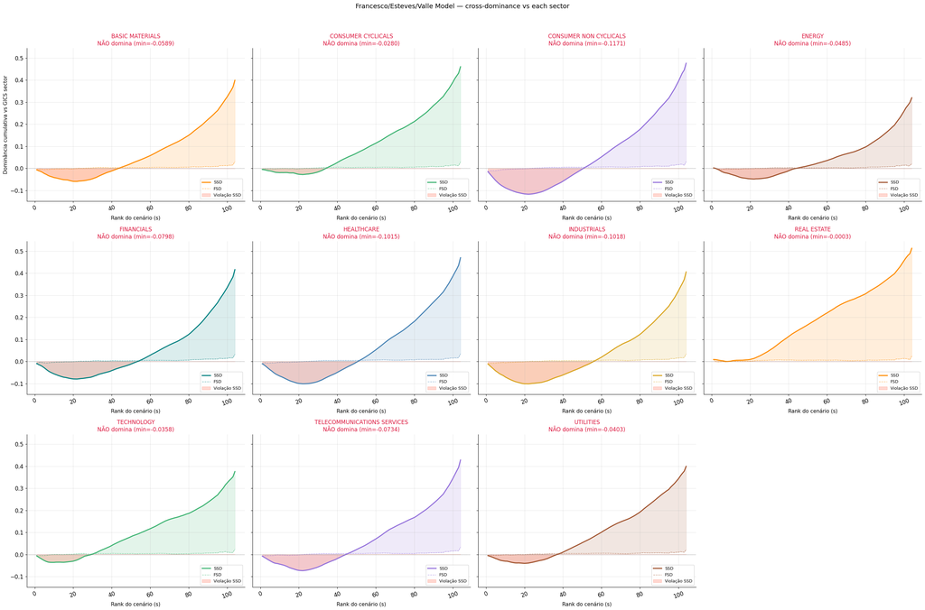

**Cross-dominance: Francesco/Esteves/Valle Model vs each individual sector**

## 10b. SSD dominance — CDFs and cumulative integrals (Francesco/Esteves/Valle Model)

Compares F(x) (portfolio CDF) vs G(x) (sectoral Synthetic Benchmark CDF):

- **Green**: G ≥ F → portfolio dominates in this region
- **Pink**: G < F → benchmark dominates in this region
- **I₂(x)**: left cumulative integral of G−F (SSD condition: I₂ ≥ 0 everywhere confirms second-order dominance)

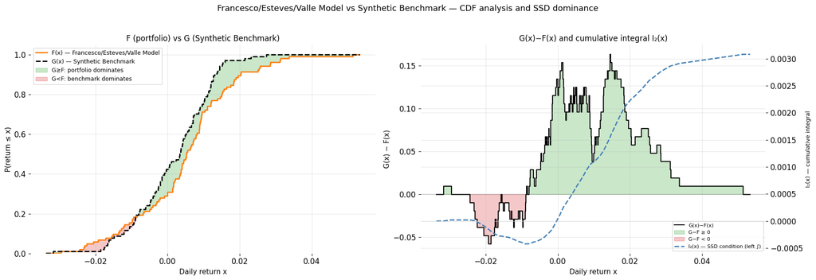

**CDFs and SSD integral: Francesco/Esteves/Valle Model vs Synthetic Benchmark**

## 10c. r_P vs r_B by quantile — tail analysis (Francesco/Esteves/Valle Model)

For each quantile threshold, separates OOS days into:

- **Worst benchmark days (blue)**: the k days with the lowest benchmark returns → measures downside protection
- **Best benchmark days (orange)**: the remaining days → measures upside capture

The β of each regression measures the sensitivity of the portfolio return to the benchmark in that region. The portfolio is compared against the **sectoral Synthetic Benchmark**, which is its optimization benchmark in the model.

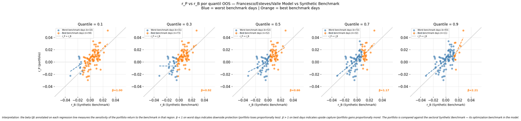

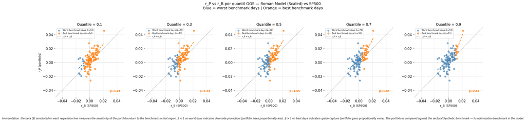

**r_P vs r_B by quantile: tail analysis**

## 11. Risk × return analysis

```
[INFO]: Plot saved → /media/toni/Dados/Git/ssd-multi/src/output/tafmssd-sectors/risk_return_all.pdf
```

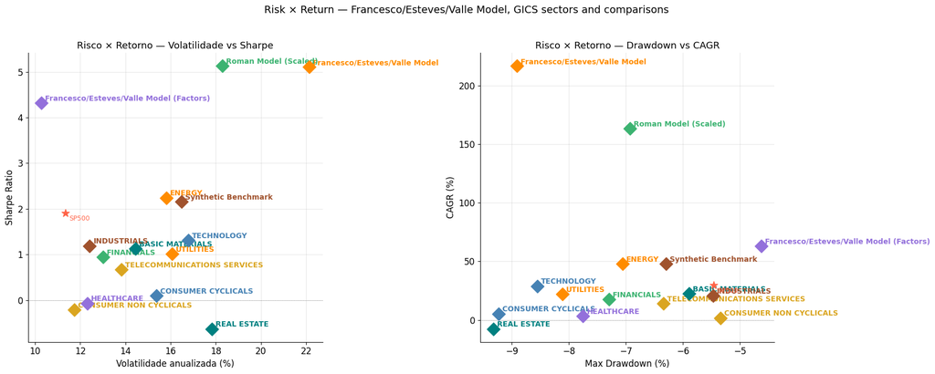

**Risk × Return (scatter)**

## 12. Return distribution and correlation

```
[INFO]: Plot saved → /media/toni/Dados/Git/ssd-multi/src/output/tafmssd-sectors/return_dist_models.pdf
```

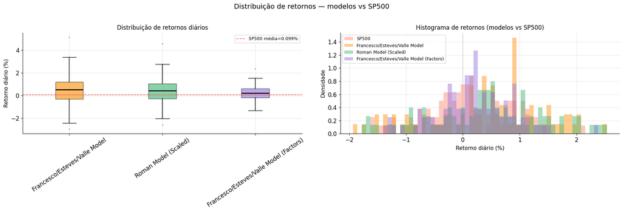

**Daily return distribution**

```
[INFO]: Plot saved → /media/toni/Dados/Git/ssd-multi/src/output/tafmssd-sectors/correlation_all.pdf
```

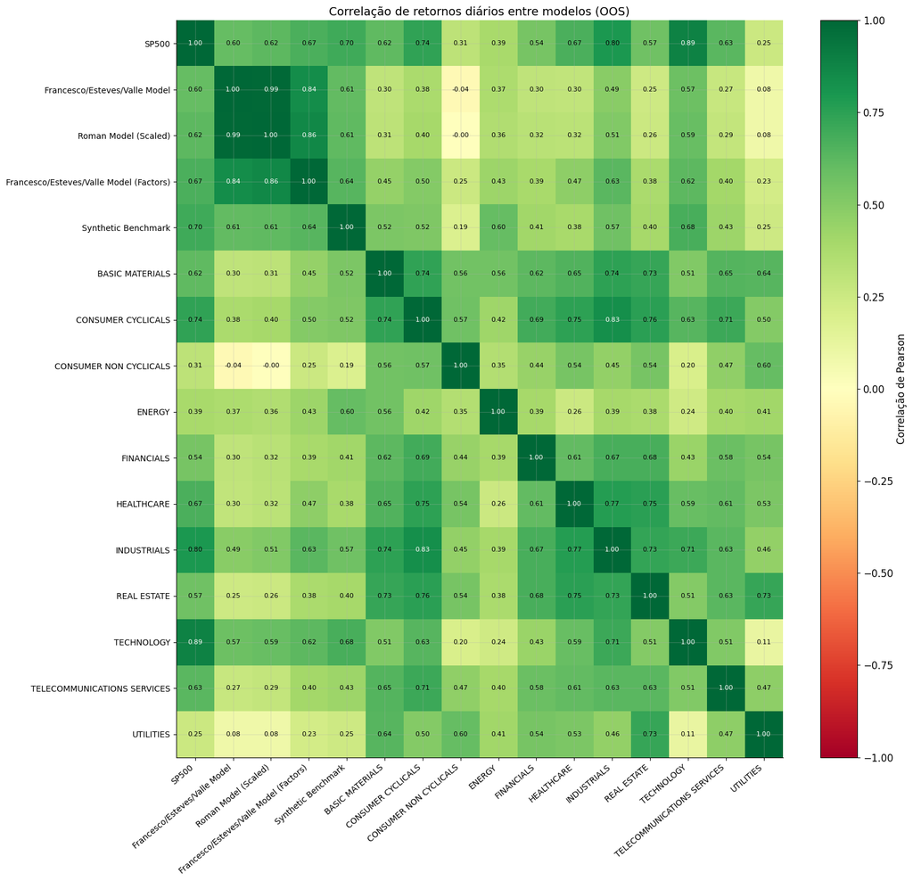

**Correlation matrix**

The heatmap reveals the correlations between daily returns of all models and sectors. Low correlation of the Francesco/Esteves/Valle Model with an individual sector indicates that the portfolio did not replicate that benchmark — probably because different sectors were binding in different training windows, generating a portfolio with diversified sectoral exposure over time. Moderate correlation with the Synthetic Benchmark is the expected pattern: high correlation would indicate that the portfolio tracks the sectoral envelope (clone behavior); very low correlation would indicate near-total independence — an aggressive diversification strategy that maximizes the gap relative to the benchmark. The block of inter-sector correlations identifies groups that share cycles (e.g., Financials and Real Estate), which may create instability in SSD constraints when rotation between them occurs. High correlation between the Francesco/Esteves/Valle Model and the Roman Model suggests that both converge to similar portfolios despite distinct benchmarks — evidence of robustness in the SSD approach; low correlation indicates that the benchmark genuinely differentiates the resulting portfolio.

## 13. Rolling returns (21 days)

```
[INFO]: Plot saved → /media/toni/Dados/Git/ssd-multi/src/output/tafmssd-sectors/rolling_returns.pdf
```

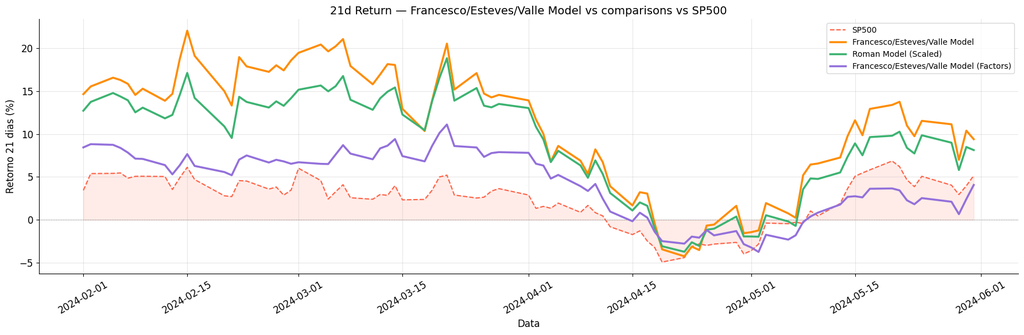

**21-day rolling returns**

The 21-day rolling return series smooths daily noise and highlights medium-term trends, revealing portfolio behavior at the time horizon that coincides with the rebalancing frequency. An SSD-robust portfolio should show monthly returns that are rarely very negative: the downside protection guaranteed in-sample should be visible on a monthly scale, not just in daily returns. Declines just before a rebalancing followed by recovery just after are expected — the model adjusts weights for the regime prevailing in the new training window. If the Francesco/Esteves/Valle Model has fewer periods with negative monthly returns than the Roman Model, the sectoral benchmark generated greater stability; the opposite would indicate that sectoral constraints reduced exposure to positive market months. Large divergences between models in specific windows point to periods where benchmark choice made a concrete difference — correlate these moments with the dominant sector in section 3b to understand whether sectoral rotation created opportunity or exposure not captured by the model.

## 14. Executive Summary

```
====================================================================================================
  EXECUTIVE SUMMARY — Francesco/Esteves/Valle Model
  OOS Period: 2024-01-01 → 2024-06-01
====================================================================================================
  Modelo                                        Final      CAGR      Vol    Sharpe    Sortino     MaxDD     Beta
  --------------------------------------------------------------------------------------------------------
  SP500 (ref)                                  1.1127   +29.54%   11.34%    1.9096     3.5279    -5.46%   1.0000
  --------------------------------------------------------------------------------------------------------
  Francesco/Esteves/Valle Model                1.6092  +216.67%   22.14%    5.1060    17.3129    -8.91%   1.1739 ◄
  Roman Model (Scaled)                         1.4911  +163.29%   18.29%    5.1260    15.2550    -6.93%   1.0043 ◄
  Francesco/Esteves/Valle Model (Factors)      1.2230   +62.88%   10.29%    4.3224     9.3841    -4.63%   0.6071 ◄
  Synthetic Benchmark                          1.1750   +47.80%   16.48%    2.1585     4.1251    -6.30%   1.0160 ◄
====================================================================================================
```

```
================================================================================
  GICS SECTORS — OOS PERFORMANCE
================================================================================
  Setor                                     Final      CAGR    Sharpe
  -----------------------------------------------------------------
  BASIC MATERIALS                          1.0867   +22.33%    1.1288
  CONSUMER CYCLICALS                       1.0215    +5.30%    0.0949
  CONSUMER NON CYCLICALS                   1.0073    +1.79%   -0.2070
  ENERGY                                   1.1750   +47.80%    2.2436
  FINANCIALS                               1.0696   +17.70%    0.9421
  HEALTHCARE                               1.0137    +3.36%   -0.0671
  INDUSTRIALS                              1.0810   +20.78%    1.1896
  REAL ESTATE                              0.9679    -7.60%   -0.6279
  TECHNOLOGY                               1.1108   +28.98%    1.3094
  TELECOMMUNICATIONS SERVICES              1.0562   +14.16%    0.6739
  UTILITIES                                1.0853   +21.94%    1.0106
================================================================================
```

## 15. Consolidated Analysis of the Experiment

### Francesco/Esteves/Valle Model with Sector Benchmarks

#### 1. About the model and the formulation

The **Francesco/Esteves/Valle Model (TAF-MultiSSD with sectoral Synthetic Benchmark)** is a natural extension of the second-order stochastic dominance (SSD) model to the multi-benchmark context. Instead of requiring the portfolio to dominate each of the 11 GICS sectors individually (which would require K separate sets of Vs variables and K lazy callbacks), the model uses a **single Synthetic Benchmark** defined as the upper envelope of the sorted cumulatives of each sector:

$$\tau_{\text{synth}}[s] = \max_k\left(\sum_{i=1}^{s} r^{(i)}_k\right)$$

where $r^{(i)}_k$ is the i-th smallest return of sector k in the training period. This compresses K constraints into a single one, preserving the mathematical coherence of SSD dominance (if the portfolio dominates the Synthetic Benchmark, it dominates any convex combination of the sectors with the same cumulative worst-case).

The solution uses **CPLEX lazy constraint callbacks**: instead of adding all S constraints `Vs_t ≤ Σ R_port − τ_synth[t]` explicitly, only the most violated are added iteratively. This is critical for scalability when S = 200 (training days) and N ≈ 505 (assets).

#### 2. Validity of in-sample dominance

In-sample SSD dominance is **guaranteed by construction** when the solver finds the optimal solution (V* is the maximum V such that `(t+1)V ≤ Vs_t` and `Vs_t ≤ Σ R_port − τ_synth[t]` for all t). The fundamental question is: **how much of this dominance generalizes to the OOS period?**

Factors favoring generalization:

- The Synthetic Benchmark is the maximum of 11 sectors — it imposes much stricter constraints than a single benchmark (SP500), forcing genuine diversification.
- The 200-day sliding window captures recent market regimes, making SSD constraints relevant for the near future.
- With 5 rebalancings, the portfolio adapts to regime changes during the OOS period.

Factors limiting generalization:

- The OOS period (104 days) may be dominated by a single sector that was not the binding constraint in-sample.
- The OOS Synthetic Benchmark is calculated as `max_k(norm_k[t])` — a slightly different definition than in-sample (which uses sorted cumulatives). The portfolio was not explicitly optimized to dominate this OOS series.

#### 3. Interpretation of cross-dominance results

The cross-dominance analysis (section 10, second panel) is particularly informative. If the portfolio dominates only some of the 11 sectors individually in OOS, this is **expected and acceptable**: the model was optimized to dominate the Synthetic Benchmark (the maximum), not each sector individually. A sector that outperformed the Synthetic Benchmark in-sample in some window would, by definition, be dominant over the portfolio.

The most favorable result would be: the portfolio SSD-dominates most sectors individually (e.g., 8/11 or more), confirming that the Synthetic Benchmark constraint is sufficiently rigid to guarantee generalized dominance.

#### 4. Tail analysis and asymmetric behavior

The r_P vs r_B scatter (section 10c) reveals the portfolio's asymmetric behavior relative to the Synthetic Benchmark. The ideal interpretation is:

- **β < 1 on the worst benchmark days**: the portfolio falls less when the Synthetic Benchmark falls — direct downside protection, consistent with the SSD constraint on the negative tails of the in-sample distribution.
- **β ≈ 1 or < 1 on the best days**: SSD optimization includes no upside incentive — unlike a return-maximization portfolio. β < 1 on the best days is an expected cost of the pure SSD approach.

#### 5. Comparison with alternative models

| Aspect | Francesco/Esteves/Valle Model (sectors) | Roman Model (Scaled) | FEV Model (Factors) |
| --- | --- | --- | --- |
| Benchmark | 11 GICS sectors (Synthetic) | SP500 | Fama-French factors (Synthetic) |
| SSD constraints | 1 set vs Synthetic | 1 set vs SP500 | 1 set vs Synthetic (factors) |
| Forced diversification | Sectoral (11 components) | Broad market | Style (value, growth, etc.) |
| Expected OOS generalization | High if sectors are stable | Moderate | High if factors are stable |

#### 6. Open questions

1. **Sector universe**: the experiment uses all 11 GICS sectors. A natural extension would be to select only the sectors most correlated with the available assets or with greater return dispersion.
2. **Sector weights**: the Synthetic Benchmark treats all sectors equally (max, not weighted average). A Synthetic Benchmark weighted by capitalization or by some risk measure could be more robust.
3. **Rebalancing horizon**: 21 days is conventional but arbitrary. More frequent rebalancings (e.g., 10 days) could improve adaptation to changes in the dominant sector.
4. **Transaction costs**: the current analysis ignores transaction costs. In concentrated portfolios (few positions with high weights), turnover between rebalancings can be significant — a cost-benefit study would be necessary for practical application.
5. **Extension of the OOS period**: 104 days is a short period for robust validation. A backtest with multiple OOS periods (e.g., 2022–2024 with full walk-forward) would be necessary for definitive conclusions.